# Q & K Box 15.1

Wu et al. (2021) took soil samples at 300 sites near the Three Gorges Reservoir in China. Each site was classified into one of three categories of land use: orchard (n = 75), dry land (n = 98), and paddy field (n = 127). They also measured the concentrations of ten metals (Ca, Cd, Cr, Cu, Fe, Mg, Mn, Ni, Pb, and Zn; mg/kg) and five soil characteristics (pH, concentrations of N and P in mg/kg, and % of soil organic carbon [SOC] and K) for each site. Wu et al. (2021) did a PCA on the metals and used the components in further analyses. Using PCA, we will instead examine the pattern among sites and land use categories based on the metals and the other characteristics (15 variables in total).

The paper is [here](https://doi.org/10.1371/journal.pone.0254928)

Wu, W., Li, Y., Yan, M., Yang, L., Lei, J. & Liu, H. B. (2021). Surface soil metal elements variability affected by environmental and soil properties. *PLoS One*, 16, e0254928.

### Preliminaries

packages: vegan, Rmisc, lmodel2, pscych; ggvegan & ggfortify for graphics

```r
source("../R/libraries.R")   #This is the common library
library(vegan)
library(ggvegan)
library(ggfortify)
library(lmodel2)
library(psych)
library(MultBiplotR)
# ggvegan is used for some graphics; it needs to be installed from github. Use the code in the next line to install it.
#remotes::install_github("gavinsimpson/ggvegan") #Use once to get ggvegan
source("../R/appearance.R")   #This is the set of graphics tweaks for figs
```

Run evplot function needed to draw broken stick graph

**Needs function from Legendre & Legendre book**

```r
source ('http://www.davidzeleny.net/anadat-r/doku.php/en:numecolr:evplot?do=export_code&codeblock=1')
```

Read in the data (wu.csv)

```r
wu <- read_csv("../data/wu.csv")
head(wu, 10)
```

| ca | cr | cu | fe | mn | pb | zn | cd | mg | ni | soc | ph | n | k | p | landuse | group |
| --- | --- | --- | --- | --- | --- | --- | --- | --- | --- | --- | --- | --- | --- | --- | --- | --- |
| 0.810 | 66.25 | 20.392 | 3.467 | 633.3 | 21.47 | 68.85 | 0.175 | 1.400 | 25.94 | 0.590 | 6.82 | 710.7 | 2.122 | 597.06 | Dryland | 1 |
| 0.466 | 43.78 | 10.294 | 2.044 | 228.9 | 22.45 | 36.47 | 0.134 | 0.482 | 13.30 | 0.840 | 6.17 | 744.7 | 1.518 | 304.95 | Paddy | 2 |
| 0.932 | 69.99 | 25.588 | 3.777 | 569.0 | 25.59 | 78.13 | 0.227 | 1.590 | 31.32 | 0.980 | 6.13 | 1122.7 | 2.610 | 701.92 | Dryland | 1 |
| 0.810 | 60.63 | 19.902 | 3.542 | 546.1 | 25.29 | 67.55 | 0.175 | 1.232 | 26.23 | 0.977 | 6.33 | 1025.9 | 2.163 | 481.50 | Orchard | 3 |
| 0.322 | 46.49 | 7.441 | 2.087 | 238.7 | 20.88 | 28.85 | 0.096 | 0.403 | 12.17 | 0.630 | 5.41 | 647.9 | 1.383 | 374.50 | Paddy | 2 |
| 0.910 | 76.13 | 24.314 | 4.045 | 832.8 | 24.12 | 77.96 | 0.185 | 1.602 | 33.02 | 0.582 | 6.92 | 657.1 | 2.413 | 682.66 | Paddy | 2 |
| 1.088 | 73.22 | 28.529 | 3.938 | 680.2 | 26.08 | 94.58 | 0.350 | 1.669 | 31.04 | 0.870 | 6.82 | 832.2 | 2.288 | 1011.15 | Dryland | 1 |
| 1.199 | 66.77 | 32.157 | 3.552 | 735.8 | 25.10 | 145.42 | 0.258 | 1.490 | 30.75 | 1.170 | 7.34 | 1346.2 | 2.475 | 2474.91 | Dryland | 1 |
| 0.400 | 44.51 | 7.794 | 1.755 | 164.6 | 20.88 | 28.92 | 0.134 | 0.381 | 10.00 | 0.860 | 5.86 | 802.4 | 1.622 | 291.04 | Paddy | 2 |
| 0.855 | 69.68 | 25.196 | 3.638 | 737.9 | 25.69 | 77.45 | 0.340 | 1.299 | 30.19 | 0.874 | 6.67 | 1015.6 | 2.298 | 892.38 | Dryland | 1 |

Quick data summary

```r
wu %>%
  summarise_all(list(Mean=mean, SD=sd, Max=max,Min=min))
```

| ca_Mean | cr_Mean | cu_Mean | fe_Mean | mn_Mean | pb_Mean | zn_Mean | cd_Mean | mg_Mean | ni_Mean | soc_Mean | ph_Mean | n_Mean | k_Mean | p_Mean | landuse_Mean | group_Mean | ca_SD | cr_SD | cu_SD | fe_SD | mn_SD | pb_SD | zn_SD | cd_SD | mg_SD | ni_SD | soc_SD | ph_SD | n_SD | … |
| --- | --- | --- | --- | --- | --- | --- | --- | --- | --- | --- | --- | --- | --- | --- | --- | --- | --- | --- | --- | --- | --- | --- | --- | --- | --- | --- | --- | --- | --- | --- |
| 0.7478733333 | 64.38746667 | 20.82442333 | 3.23216 | 527.0303333 | 25.52546667 | 68.22283333 | 0.22119 | 1.123736667 | 25.79336667 | 0.7868033333 | 6.255733333 | 888.3353333 | 2.06397 | 627.6393333 | NA | 1.923333333 | 0.2895654176 | 10.82057604 | 5.882028973 | 0.6651045944 | 198.1941595 | 2.308032386 | 18.21474282 | 0.06923843178 | 0.4167135562 | 7.629094131 | 0.208732834 | 0.8268300644 | 243.6480914 | … |

### Diagnostic checks

Correlation and scatterplot matrices

```r
wu.cor<-cor(wu[,c('ca','cd','cr','cu','fe','mg','mn','ni','pb','zn','ph','soc','n','p','k')])
options(digits = 2)
wu.cor
```

```
        ca   cd    cr     cu    fe     mg    mn    ni    pb    zn     ph    soc      n      p      k
ca   1.000 0.41 0.503  0.670  0.69  0.809  0.72  0.68 0.200 0.737  0.686 -0.242 -0.074  0.473  0.712
cd   0.414 1.00 0.483  0.515  0.46  0.489  0.37  0.51 0.487 0.624  0.324  0.246  0.426  0.297  0.481
cr   0.503 0.48 1.000  0.843  0.87  0.787  0.59  0.90 0.646 0.763  0.306  0.024  0.250  0.252  0.735
cu   0.670 0.52 0.843  1.000  0.90  0.882  0.72  0.89 0.626 0.893  0.346 -0.057  0.175  0.466  0.813
fe   0.691 0.46 0.869  0.904  1.00  0.918  0.78  0.93 0.631 0.878  0.347 -0.111  0.151  0.363  0.844
mg   0.809 0.49 0.787  0.882  0.92  1.000  0.79  0.92 0.470 0.887  0.477 -0.174  0.075  0.425  0.919
mn   0.722 0.37 0.590  0.724  0.78  0.794  1.00  0.72 0.338 0.727  0.383 -0.340 -0.184  0.398  0.726
ni   0.677 0.51 0.897  0.888  0.93  0.917  0.72  1.00 0.608 0.852  0.434 -0.103  0.168  0.315  0.869
pb   0.200 0.49 0.646  0.626  0.63  0.470  0.34  0.61 1.000 0.589  0.024  0.311  0.500  0.202  0.494
zn   0.737 0.62 0.763  0.893  0.88  0.887  0.73  0.85 0.589 1.000  0.393  0.013  0.242  0.559  0.841
ph   0.686 0.32 0.306  0.346  0.35  0.477  0.38  0.43 0.024 0.393  1.000 -0.098 -0.041  0.148  0.449
soc -0.242 0.25 0.024 -0.057 -0.11 -0.174 -0.34 -0.10 0.311 0.013 -0.098  1.000  0.722 -0.042 -0.131
n   -0.074 0.43 0.250  0.175  0.15  0.075 -0.18  0.17 0.500 0.242 -0.041  0.722  1.000  0.039  0.088
p    0.473 0.30 0.252  0.466  0.36  0.425  0.40  0.32 0.202 0.559  0.148 -0.042  0.039  1.000  0.409
k    0.712 0.48 0.735  0.813  0.84  0.919  0.73  0.87 0.494 0.841  0.449 -0.131  0.088  0.409  1.000
```

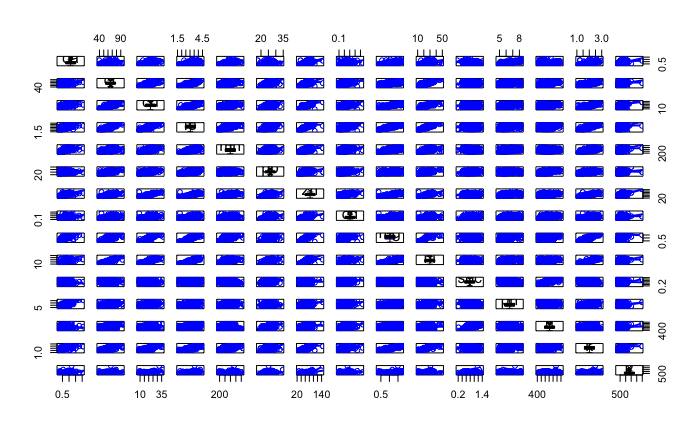

```r
scatterplotMatrix(~ca+cr+cu+fe+mn+pb+zn+cd+mg+ni+soc+ph+n+k+p,data=wu,diagonal=list(method='boxplot'))
```

```r
wu1.rma <- lmodel2(cu~mn, data=wu)
```

```
RMA was not requested: it will not be computed.

No permutation test will be performed
```

```r
print(wu1.rma)
```

```
Model II regression

Call: lmodel2(formula = cu ~ mn, data = wu)

n = 300   r = 0.72   r-square = 0.52
Parametric P-values:   2-tailed = 5.4e-50    1-tailed = 2.7e-50
Angle between the two OLS regression lines = 1.1 degrees

Regression results
```

| Method | Intercept | Slope | Angle (degrees) | P-perm (1-tailed) |
| --- | --- | --- | --- | --- |
| OLS | 9.499514189 | 0.02148815434 | 1.230991110 | NA |
| MA | 9.494768692 | 0.02149715856 | 1.231506776 | NA |
| SMA | 5.183156720 | 0.02967811457 | 1.699931731 | NA |

```
Confidence intervals
```

| Method | 2.5%-Intercept | 97.5%-Intercept | 2.5%-Slope | 97.5%-Slope |
| --- | --- | --- | --- | --- |
| OLS | 8.185776181 | 10.813252197 | 0.01915448062 | 0.02382182806 |
| MA | 8.264271403 | 10.725142531 | 0.01916261772 | 0.02383193364 |
| SMA | 3.904958489 | 6.364792162 | 0.02743605113 | 0.03210339856 |

```
Eigenvalues: 39299 16

H statistic used for computing C.I. of MA: 5.4e-06
```

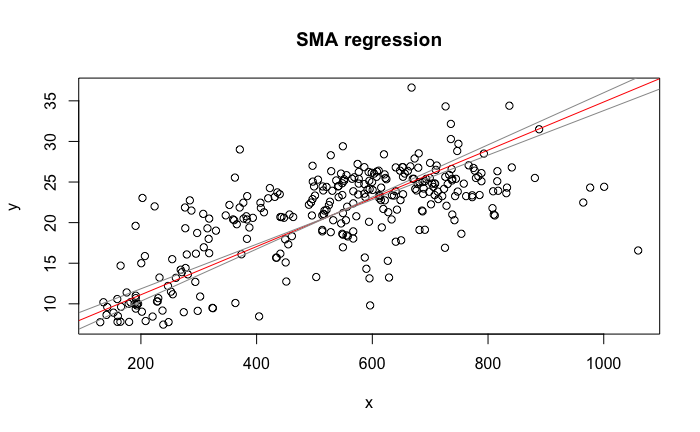

```r
plot(wu1.rma, method="SMA")
```

Check factorability of correlation matrix with Bartlett and KMO tests

```r
cortest.bartlett(wu.cor, n=300)
```

```
$chisq
[1] 5543

$p.value
[1] 0

$df
[1] 105
```

```r
KMO(wu.cor)
```

```
Kaiser-Meyer-Olkin factor adequacy
Call: KMO(r = wu.cor)
Overall MSA =  0.9
MSA for each item =
  ca   cd   cr   cu   fe   mg   mn   ni   pb   zn   ph  soc    n    p    k
0.87 0.89 0.91 0.96 0.91 0.90 0.95 0.93 0.88 0.93 0.76 0.68 0.69 0.84 0.93
```

## Do PCA on correlation matrix; get summary with scaling=2

Scaling=2 is the rda default: angles between variables match their correlations)

### Get eigenvalues

```r
wu1.rda <- rda(wu[,c('ca','cd','cr','cu','fe','mg','mn','ni','pb','zn','ph','soc','n','p','k')],scale=TRUE)
summary(wu1.rda)
```

```
Call:
rda(X = wu[, c("ca", "cd", "cr", "cu", "fe", "mg", "mn", "ni",      "pb", "zn", "ph", "soc", "n", "p", "k")], scale = TRUE)

Partitioning of correlations:
              Inertia Proportion
Total              15          1
Unconstrained      15          1

Eigenvalues, and their contribution to the correlations

Importance of components:
                        PC1   PC2    PC3    PC4    PC5    PC6    PC7    PC8    PC9   PC10    PC11    PC12   PC13    PC14    PC15
Eigenvalue            8.569 2.372 1.0935 0.9056 0.4962 0.3174 0.3029 0.2471 0.2141 0.1577 0.10979 0.07509 0.0584 0.04970 0.03206
Proportion Explained  0.571 0.158 0.0729 0.0604 0.0331 0.0212 0.0202 0.0165 0.0143 0.0105 0.00732 0.00501 0.0039 0.00331 0.00214
Cumulative Proportion 0.571 0.729 0.8023 0.8626 0.8957 0.9169 0.9371 0.9535 0.9678 0.9783 0.98565 0.99065 0.9945 0.99786 1.00000

Scaling 2 for species and site scores
* Species are scaled proportional to eigenvalues
* Sites are unscaled: weighted dispersion equal on all dimensions
* General scaling constant of scores:  8.2


Species scores

       PC1      PC2     PC3     PC4     PC5      PC6
ca  -1.673  0.73464 -0.7817  0.0336 -0.1795 -0.10080
cd  -1.283 -0.80689 -0.7180 -0.0338  1.2602 -0.06146
cr  -1.809 -0.36026  0.5440  0.3633 -0.1300  0.14124
cu  -1.978 -0.09496  0.2925 -0.1301 -0.1069  0.06529
fe  -2.002  0.00608  0.4533  0.1152 -0.1312 -0.07707
mg  -2.021  0.29000  0.0449  0.0925 -0.1401 -0.31282
mn  -1.700  0.74984  0.1832 -0.1320  0.2750 -0.22042
ni  -1.996 -0.02427  0.3224  0.3420 -0.0996  0.00575
pb  -1.303 -1.18080  0.6479 -0.0177  0.1238  0.79576
zn  -1.997 -0.16899 -0.1105 -0.3183  0.0180 -0.15278
ph  -1.032  0.57411 -1.3614  0.8911 -0.2562  0.52991
soc  0.159 -1.81601 -0.5575  0.0235 -0.4705 -0.25071
n   -0.381 -1.87092 -0.3566  0.0755 -0.2315 -0.26461
p   -1.028  0.16134 -0.5502 -1.6814 -0.2706  0.29399
k   -1.919  0.18927  0.0555  0.0808 -0.1221 -0.26439
```

[output cut: 157 more lines]

```
sit153 -0.32830  0.35191  0.423870 -0.46352 -0.30743 -0.51420
sit154 -0.35031  0.20057  0.511371 -0.23284 -0.44792 -0.13179
sit155 -0.50918 -0.05686  0.461419 -0.22569 -0.05643  0.20794
sit156 -0.22932  0.55058  0.719307  0.13361 -0.07677  0.05101
sit157 -0.32926  0.06499  0.514853 -0.35162 -0.11231 -0.63351
sit158  0.10676  0.77199  0.175105  0.65119 -0.20209  0.04840
sit159  0.22178 -0.39901  0.176988 -0.14964  0.06892  0.70598
sit160 -0.09656  0.28713  0.001792 -0.67271 -0.40999 -0.67553
sit161 -0.14484  0.65892 -1.067084  0.13818 -1.21213  0.97429
sit162 -0.04209  0.82201 -0.369958  0.21862  0.17951  0.20013
sit163 -0.22525  0.35089 -0.309984  0.59043 -1.24412  0.21428
sit164 -0.21363 -0.48561  0.662880  0.17333 -0.00848  0.12093
sit165 -0.31852  0.37698  0.205071 -0.33142  0.41930 -0.35217
sit166  0.40735 -0.16938  0.519018 -0.46086 -0.33392  0.04749
 [ reached getOption("max.print") -- omitted 134 rows ]
```

```r
wu1.eig <- wu1.rda$CA$eig
wu1.eig
```

```
  PC1   PC2   PC3   PC4   PC5   PC6   PC7   PC8   PC9  PC10  PC11  PC12  PC13  PC14  PC15
8.569 2.372 1.094 0.906 0.496 0.317 0.303 0.247 0.214 0.158 0.110 0.075 0.058 0.050 0.032
```

### Get scree and broken stick plots

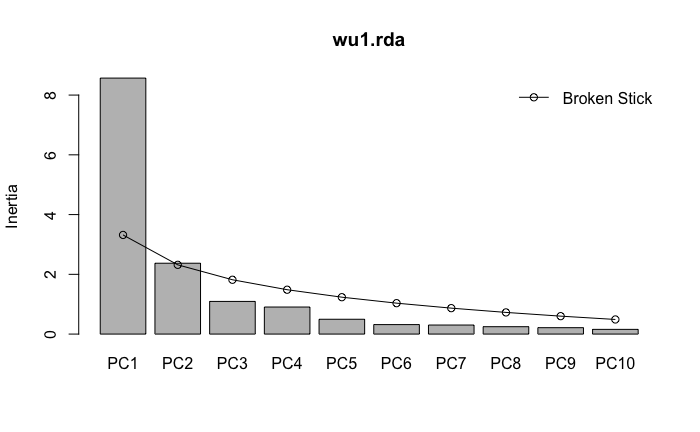

```r
screeplot(wu1.rda,bstick=TRUE, bst.col="black",xlab = "Component", ylab = "Inertia",)
```

```r
bstick(wu1.rda)
```

```
  PC1   PC2   PC3   PC4   PC5   PC6   PC7   PC8   PC9  PC10  PC11  PC12  PC13  PC14  PC15
3.318 2.318 1.818 1.485 1.235 1.035 0.868 0.725 0.600 0.489 0.389 0.298 0.215 0.138 0.067
```

#### Alternative run evplot function to draw broken stick graph

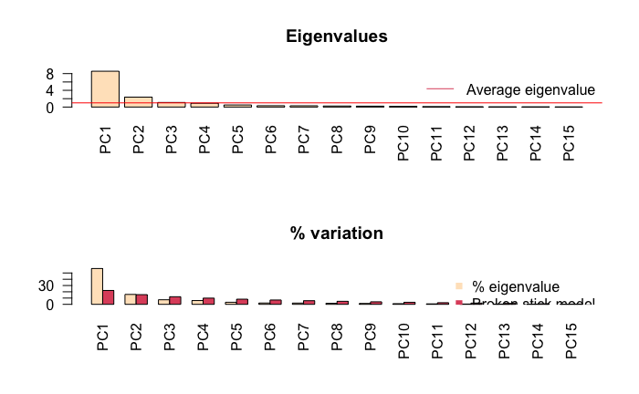

```r
evplot(wu1.eig)
```

### Retain the first 2 or 3 components

Get eigenvectors coefficients This can be done in two ways:

```r
scores(wu1.rda, choices=c(1:3), display='species', scaling = 0)
```

```
       PC1     PC2    PC3
ca  -0.270  0.2258 -0.354
cd  -0.207 -0.2480 -0.325
cr  -0.292 -0.1107  0.246
cu  -0.320 -0.0292  0.132
fe  -0.324  0.0019  0.205
mg  -0.327  0.0891  0.020
mn  -0.275  0.2304  0.083
ni  -0.323 -0.0075  0.146
pb  -0.211 -0.3629  0.293
zn  -0.323 -0.0519 -0.050
ph  -0.167  0.1764 -0.616
soc  0.026 -0.5581 -0.252
n   -0.062 -0.5749 -0.161
p   -0.166  0.0496 -0.249
k   -0.310  0.0582  0.025
attr(,"const")
[1] 8.2
```

```r
# alternatively
wu1.vec <- eigen(wu.cor)
print(wu1.vec)
```

```
eigen() decomposition
$values
 [1] 8.569 2.372 1.094 0.906 0.496 0.317 0.303 0.247 0.214 0.158 0.110 0.075 0.058 0.050 0.032

$vectors
        [,1]    [,2]   [,3]    [,4]   [,5]    [,6]    [,7]   [,8]    [,9]  [,10]  [,11]   [,12]  [,13]   [,14]   [,15]
 [1,] -0.270  0.2258  0.354 -0.0167  0.121 -0.0847  0.1746  0.247 -0.2036  0.533  0.429  0.2002 -0.221  0.1397 -0.1364
 [2,] -0.207 -0.2480  0.325  0.0168 -0.847 -0.0516 -0.1428 -0.135  0.0426  0.054  0.073  0.0711  0.076 -0.0937 -0.0430
 [3,] -0.292 -0.1107 -0.246 -0.1807  0.087  0.1186 -0.3525 -0.452 -0.2734 -0.151  0.343  0.0084 -0.463 -0.0058  0.1696
 [4,] -0.320 -0.0292 -0.132  0.0647  0.072  0.0548 -0.0741 -0.150 -0.1660  0.267 -0.671  0.5210 -0.039 -0.0319 -0.1276
 [5,] -0.324  0.0019 -0.205 -0.0573  0.088 -0.0647  0.0653  0.029 -0.1635  0.061  0.107 -0.2946  0.273 -0.6903 -0.3910
 [6,] -0.327  0.0891 -0.020 -0.0460  0.094 -0.2628 -0.0658  0.090  0.1362  0.082  0.051  0.1097  0.346 -0.1696  0.7771
 [7,] -0.275  0.2304 -0.083  0.0656 -0.185 -0.1852  0.6527 -0.058 -0.2594 -0.514 -0.035  0.0822 -0.079  0.1272  0.0341
 [8,] -0.323 -0.0075 -0.146 -0.1701  0.067  0.0048 -0.1991 -0.051  0.0205 -0.083  0.138 -0.0320  0.568  0.6059 -0.2864
 [9,] -0.211 -0.3629 -0.293  0.0088 -0.083  0.6685  0.3467  0.278  0.1947  0.117  0.110  0.0235 -0.028  0.0350  0.1420
[10,] -0.323 -0.0519  0.050  0.1583 -0.012 -0.1283  0.0062  0.019  0.0154  0.224 -0.355 -0.7314 -0.253  0.2487  0.1048
[11,] -0.167  0.1764  0.616 -0.4432  0.172  0.4451 -0.0081 -0.053  0.0103 -0.253 -0.210 -0.0987  0.048 -0.1101  0.0417
[12,]  0.026 -0.5581  0.252 -0.0117  0.316 -0.2106  0.3950 -0.513  0.1779  0.111  0.074  0.0324  0.096  0.0082 -0.0291
[13,] -0.062 -0.5749  0.161 -0.0375  0.156 -0.2223 -0.1738  0.553 -0.3399 -0.312 -0.062  0.0772 -0.075  0.0156 -0.0086
[14,] -0.166  0.0496  0.249  0.8362  0.182  0.2470 -0.1710 -0.087 -0.0068 -0.213  0.128  0.0341  0.112 -0.0457 -0.0121
[15,] -0.310  0.0582 -0.025 -0.0402  0.082 -0.2221 -0.0967  0.149  0.7456 -0.234  0.025  0.1527 -0.334 -0.0666 -0.2459
```

Get true loadings as correlations; can also be done in a couple of ways

```r
wu1.load <- eigen.loadings(wu1.vec)
print(wu1.load)
```

```
        [,1]    [,2]   [,3]    [,4]    [,5]    [,6]    [,7]    [,8]    [,9]  [,10]   [,11]   [,12]   [,13]   [,14]   [,15]
 [1,] -0.792  0.3477  0.370 -0.0159  0.0849 -0.0477  0.0961  0.1226 -0.0942  0.212  0.1423  0.0549 -0.0534  0.0312 -0.0244
 [2,] -0.607 -0.3819  0.340  0.0160 -0.5964 -0.0291 -0.0786 -0.0672  0.0197  0.021  0.0240  0.0195  0.0185 -0.0209 -0.0077
 [3,] -0.856 -0.1705 -0.257 -0.1719  0.0615  0.0668 -0.1940 -0.2246 -0.1265 -0.060  0.1137  0.0023 -0.1120 -0.0013  0.0304
 [4,] -0.936 -0.0449 -0.138  0.0616  0.0506  0.0309 -0.0408 -0.0745 -0.0768  0.106 -0.2223  0.1428 -0.0093 -0.0071 -0.0229
 [5,] -0.947  0.0029 -0.215 -0.0545  0.0621 -0.0365  0.0360  0.0143 -0.0757  0.024  0.0354 -0.0807  0.0661 -0.1539 -0.0700
 [6,] -0.957  0.1372 -0.021 -0.0438  0.0663 -0.1480 -0.0362  0.0448  0.0630  0.032  0.0171  0.0301  0.0837 -0.0378  0.1392
 [7,] -0.804  0.3549 -0.087  0.0625 -0.1302 -0.1043  0.3592 -0.0286 -0.1200 -0.204 -0.0115  0.0225 -0.0190  0.0284  0.0061
 [8,] -0.945 -0.0115 -0.153 -0.1618  0.0471  0.0027 -0.1096 -0.0253  0.0095 -0.033  0.0457 -0.0088  0.1373  0.1351 -0.0513
 [9,] -0.617 -0.5588 -0.307  0.0084 -0.0586  0.3766  0.1908  0.1384  0.0901  0.046  0.0363  0.0064 -0.0067  0.0078  0.0254
[10,] -0.945 -0.0800  0.052  0.1507 -0.0085 -0.0723  0.0034  0.0093  0.0071  0.089 -0.1176 -0.2004 -0.0612  0.0555  0.0188
[11,] -0.488  0.2717  0.644 -0.4217  0.1212  0.2508 -0.0044 -0.0263  0.0048 -0.101 -0.0697 -0.0270  0.0117 -0.0245  0.0075
[12,]  0.075 -0.8595  0.264 -0.0111  0.2227 -0.1187  0.2174 -0.2550  0.0823  0.044  0.0244  0.0089  0.0232  0.0018 -0.0052
[13,] -0.180 -0.8854  0.169 -0.0357  0.1096 -0.1252 -0.0957  0.2750 -0.1573 -0.124 -0.0204  0.0211 -0.0181  0.0035 -0.0015
[14,] -0.487  0.0764  0.260  0.7958  0.1281  0.1391 -0.0941 -0.0432 -0.0031 -0.085  0.0424  0.0094  0.0271 -0.0102 -0.0022
[15,] -0.908  0.0896 -0.026 -0.0382  0.0578 -0.1251 -0.0532  0.0739  0.3450 -0.093  0.0082  0.0418 -0.0806 -0.0148 -0.0440
```

```r
# can also get loadings from principal in psych package
wu1.pca <- principal(wu.cor, n.obs=300, nfactors=3, rotate="none", residuals=TRUE)
print(wu1.pca)
```

```
Principal Components Analysis
Call: principal(r = wu.cor, nfactors = 3, residuals = TRUE, rotate = "none",
    n.obs = 300)
Standardized loadings (pattern matrix) based upon correlation matrix
```

|  | PC1 | PC2 | PC3 | h2 | u2 | com |
| --- | --- | --- | --- | --- | --- | --- |
| ca | 0.79 | -0.35 | 0.37 | 0.8845862670 | 0.11541373297 | 1.835596350 |
| cd | 0.61 | 0.38 | 0.34 | 0.6298741304 | 0.37012586961 | 2.327561253 |
| cr | 0.86 | 0.17 | -0.26 | 0.8281099624 | 0.17189003763 | 1.264854381 |
| cu | 0.94 | 0.04 | -0.14 | 0.8979038091 | 0.10209619091 | 1.048407239 |
| fe | 0.95 | 0.00 | -0.21 | 0.9433137003 | 0.05668629974 | 1.102346847 |
| mg | 0.96 | -0.14 | -0.02 | 0.9344486336 | 0.06555136638 | 1.042155874 |
| mn | 0.80 | -0.35 | -0.09 | 0.7806095962 | 0.21939040379 | 1.401692637 |
| ni | 0.94 | 0.01 | -0.15 | 0.9158885279 | 0.08411147214 | 1.052426971 |
| pb | 0.62 | 0.56 | -0.31 | 0.7866978982 | 0.21330210184 | 2.465080593 |
| zn | 0.95 | 0.08 | 0.05 | 0.9027438339 | 0.09725616609 | 1.020479477 |

[output cut: 5 more lines]

```
                       PC1  PC2  PC3
SS loadings           8.57 2.37 1.09
Proportion Var        0.57 0.16 0.07
Cumulative Var        0.57 0.73 0.80
Proportion Explained  0.71 0.20 0.09
Cumulative Proportion 0.71 0.91 1.00

Mean item complexity =  1.5
Test of the hypothesis that 3 components are sufficient.

The root mean square of the residuals (RMSR) is  0.05
 with the empirical chi square  141  with prob <  6.2e-08

Fit based upon off diagonal values = 0.99
```

Get correlation residuals - two methods from psych package

```r
residuals(wu1.pca, diag=TRUE)
```

```
    ca    cd    cr    cu    fe    mg    mn    ni    pb    zn    ph    soc   n     p     k
ca   0.12
cd  -0.06  0.37
cr  -0.02 -0.01  0.17
cu   0.00 -0.02  0.00  0.10
fe   0.02 -0.04  0.00 -0.01  0.06
mg   0.01 -0.03 -0.01 -0.01  0.01  0.07
mn  -0.01  0.05 -0.06 -0.03  0.00 -0.03  0.22
ni  -0.01 -0.02  0.05 -0.02  0.00  0.01 -0.05  0.08
pb   0.02  0.00 -0.06 -0.02 -0.02 -0.05  0.01 -0.03  0.21
zn   0.00  0.00 -0.05  0.01 -0.01 -0.01  0.00 -0.03 -0.02  0.10
ph  -0.03 -0.09  0.10 -0.01  0.02 -0.01 -0.05  0.07  0.07 -0.08  0.27
soc  0.02 -0.13  0.01  0.01  0.02  0.02  0.05  0.00 -0.04  0.00  0.00  0.19
n    0.03 -0.08 -0.01 -0.01  0.02  0.03  0.00  0.01 -0.05 -0.01  0.00 -0.07  0.15
p   -0.04 -0.06 -0.08  0.05 -0.04 -0.05  0.00 -0.10  0.02  0.09 -0.28 -0.01 -0.02  0.69
k   -0.03 -0.03 -0.03 -0.04 -0.02  0.04 -0.04  0.01 -0.02 -0.01  0.00  0.02  0.01 -0.03  0.17
```